# Design report

**Alignment size:** 100 sequences  
**Length of alignment/region of interest:** 2001 nucleotides  
**Report generated:** 2020-09-01 15:17:27  
**Comment:**

### Assay information

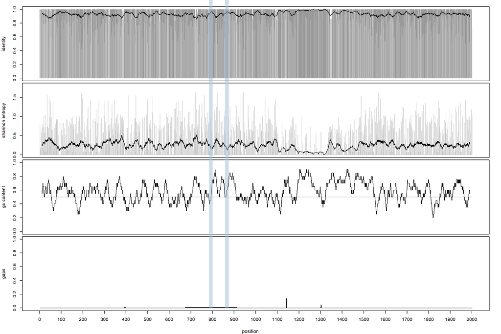

**Fig. 1.** Assay location (blue) and target information. *Identity:* Proportion of the most frequently occuring base. *Entropy:* Shannon entropy, a measurement of variability. A value of zero indicate no variability and a high value indicate high variability. *GC:* GC-content. *Gaps:* Proportion of gaps. Vertical bars represent the value at each position. Black bars in the two uppermost figures represent values of 1 and 0, respectively (i.e. positions with complete conservation). Horizontal lines represent centered running averages.

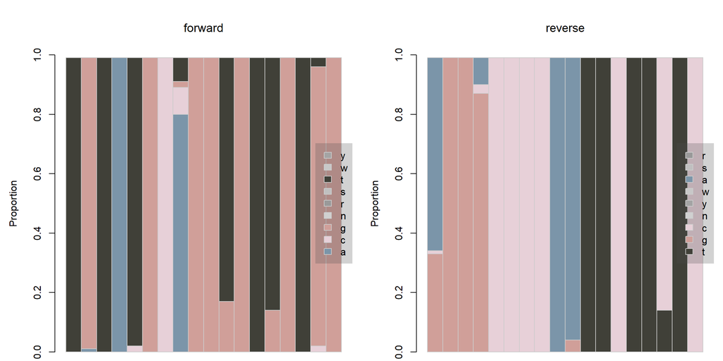

**Fig. 2.** Proportion of each nucleotide in the alignment at the oligo binding sites. Sequences are displayed from 5’- to 3’-end.  
**Table 1**. Assay information. *Begin:* Where the assay region starts (with regards to the alignment/region of interest), *End:* Where the assay region ends. *Tm difference, primers:* Tm difference between the two primers (absolute value, in C). *Tm difference, probe-primers:* Tm of the probe subtracted by the average Tm of the primer pair. Note that tm-differences are calculated from majority oligos and may therefore be misleading for degenerate (IUPAC) oligos. *Degeneracy:* Total number of oligo variants in the assay. *Perfect match:* Proportion of perfectly matching sequences.

| Begin | End | Amplicon length | Tm difference, primers | Degeneracy | Perfect match (majority) | Perfect match (IUPAC) |
| --- | --- | --- | --- | --- | --- | --- |
| 784 | 875 | 92 | 1.31 | 8 | 0.59 | 0.69 |

**Table 2.** Forward primer, summary.

| Begin | End | Length | Sequence (majority) | Sequence (IUPAC) | Degenerates | Degeneracy | GC-content (majority) | Tm (majority) | Perfect matches (majority) | Perfect matches (IUPAC) |
| --- | --- | --- | --- | --- | --- | --- | --- | --- | --- | --- |
| 784 | 801 | 18 | tgtatgcaggtgttgtgg | tgtatgcaggkgtkgtgg | 2 | 4 | 0.5 | 54.75 | 0.79 | 0.79 |

**Table 3.** Forward primer, all variants.

| Variant | GC-content | Tm |
| --- | --- | --- |
| tgtatgcaggggtggtgg | 0.61 | 58.84 |
| tgtatgcaggtgtggtgg | 0.56 | 56.79 |
| tgtatgcaggggttgtgg | 0.56 | 56.76 |
| tgtatgcaggtgttgtgg | 0.50 | 54.75 |

**Table 4.** Forward primer, mean values.

| gc_content | 0.56 |
| --- | --- |
| tm | 56.78 |

**Table 5.** Reverse primer, summary.

| Begin | End | Length | Sequence (majority) | Sequence (IUPAC) | Degenerates | Degeneracy | GC-content (majority) | Tm (majority) | Perfect matches (majority) | Perfect matches (IUPAC) |
| --- | --- | --- | --- | --- | --- | --- | --- | --- | --- | --- |
| 858 | 875 | 18 | agggccccaattcttctc | rgggccccaattcttytc | 2 | 4 | 0.56 | 56.06 | 0.61 | 0.86 |

**Table 6.** Reverse primer, all variants.

| Variant | GC-content | Tm |
| --- | --- | --- |
| agggccccaattcttctc | 0.56 | 56.06 |
| ggggccccaattcttctc | 0.61 | 57.24 |
| agggccccaattcttttc | 0.50 | 54.61 |
| ggggccccaattcttttc | 0.56 | 55.81 |

**Table 7.** Reverse primer, mean values.

| gc_content | 0.56 |
| --- | --- |
| tm | 55.93 |

### Amplicon information

**Sequence:** tgtatgcaggtgttgtggtggcccccggccttggcgcgcttcctgatgttgtgcgcttcgccggccggcttaccgagaagaattggggccct  
**Length:** 92  
**GC-content:** 64 %  
**Does the amplicon contain more than 3 consecutive G:s?** Yes  
The data is based on the majority consensus sequence.

### Match information (in silico inclusivity)

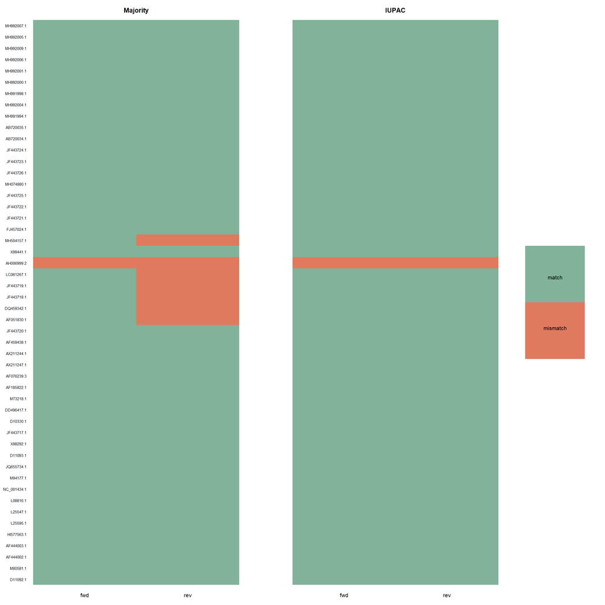

**Fig. 3.** Matching and mismatching target sequences.

### Target sequences

The assay was designed from the following target sequences:  
D11092.1, M80581.1, AF444002.1, AF444003.1, HI577563.1, L25595.1, L25547.1, L08816.1, NC_001434.1, M94177.1, JQ655734.1, D11093.1, X98292.1, JF443717.1, D10330.1, DD496417.1, M73218.1, AF185822.1, AF076239.3, AX211247.1, AX211244.1, AF459438.1, JF443720.1, AF051830.1, DQ459342.1, JF443718.1, JF443719.1, LC061267.1, AH006999.2, X99441.1, MH504157.1, FJ457024.1, JF443721.1, JF443722.1, JF443725.1, MH074880.1, JF443726.1, JF443723.1, JF443724.1, AB720034.1, AB720035.1, MH991994.1, MH992004.1, MH991998.1, MH992000.1, MH992001.1, MH992006.1, MH992009.1, MH992005.1, MH992007.1, MH992011.1, MH991993.1, MH991995.1, MH991997.1, MH991996.1, MH992008.1, MH992010.1, MH992012.1, MH992013.1, MH992003.1, MH992002.1, MH991999.1, MH504154.1, MH504162.1, LC225387.1, LC314158.1, MH504155.1, MH504159.1, MH504160.1, MH504161.1, MN401238.1, LC314156.1, MH504156.1, MH504158.1, MH504163.1, KY436505.1, KY436507.1, KY436506.1, LC314157.1, LC314155.1, AY230202.1, AY204877.1, MH918640.1, M74506.1, KX578717.1, MH809516.1, AF082843.1, AY575857.1, AY575858.1, AY575859.1, KT447526.1, KT447528.1, AF060668.1, AX181807.1, AX181808.1, BD378054.1, BD378055.1, AB481228.1, AB074918.2, LF848974.1.